# Relatório - Modelos Lineares Generalizados e Aditivos para Dados Ecológicos

Layla Paiva de Almeida

20 outubro, 2025

## 1 Introdução aos GMLs

GLMs permitem a modelagem de variáveis dependentes que não seguem a distribuição normal. Seu principal objetivo é encontrar a relação entre uma variável dependente (Y) e uma ou mais variáveis independentes (X)

## 2 Modelo Linear Generalizado para Dados Binários

Dados binários são aqueles que se apresentam em apenas duas possibilidades ou estados,Como por exemplo presença/ausência. São dados os quais podem ser substituídos por representações de 0 ou 1, sendo descritos por distribuição binomial.

## 3 Na prática

Utilizando os dados disponíveis na pasta `/Dados` da disciplina, escolhi a base de dados `/koalas.rds`, referente a um estudo sobre o impacto de ameaças na distribuição de coalas na Austrália, especificamente a desflorestação e degradação das florestas e a urbanização.

```r
# 1. Importando o banco de dados
dados <- readRDS("~/Disciplinas do Mestrado/ECL0072 - MODELOS LINEARES GENERALIZADOS E ADITIVOS PARA DADOS ECOLÓGICOS/ECL0072-GLM_GAM-gh-pages/ECL0072-GLM_GAM-gh-pages/Dados/koalas.rds")
```

Portanto a pergunta da nossa análise será: A qualidade do habitat e o nível de Urbanização influenciam a ocorrência dos coalas australianos?

Nesse sentido, a variável dependente (Y) será a ocorrência de coalas, sendo nossa variável binária, definida pela presença ou ausência do animal.

Já as variáveis independentes (X) serão qualidade do habitat e nível de urbanização.

## 4 Análise Exploratória

Agora que tenho a pergunta da análise e os dados, preciso entender como estes se dispõem no arquivo.

```r
# Análise Exploratória
str(dados)
```

```
## 'data.frame':    301 obs. of  22 variables:
##  $ V1 : chr  "site" "1" "1" "1" ...
##  $ V2 : chr  "subsite" "1" "2" "3" ...
##  $ V3 : chr  "easting" "510396" "510356" "510329" ...
##  $ V4 : chr  "northing" "7081160" "7081052" "7080920" ...
##  $ V5 : chr  "presence" "1" "1" "1" ...
##  $ V6 : chr  "pprim_ssite" "0.00" "0.00" "0.00" ...
##  $ V7 : chr  "psec_ssite" "20.00" "15.00" "0.00" ...
##  $ V8 : chr  "phss_5km" "9.55" "9.88" "10.08" ...
##  $ V9 : chr  "phss_2.5km" "2.27" "2.56" "2.85" ...
##  $ V10: chr  "phss_1km" "7.58" "8.90" "9.61" ...
##  $ V11: chr  "pm_5km" "12.86" "12.90" "13.00" ...
##  $ V12: chr  "pm_2.5km" "26.84" "27.15" "27.50" ...
##  $ V13: chr  "pm_1km" "86.76" "85.39" "84.59" ...
##  $ V14: chr  "pdens_5km" "0.30" "0.30" "0.29" ...
##  $ V15: chr  "pdens_2.5km" "0.25" "0.25" "0.41" ...
##  $ V16: chr  "pdens_1km" "0.64" "1.59" "0.95" ...
##  $ V17: chr  "edens_5km" "13.67" "13.75" "13.85" ...
##  $ V18: chr  "edens_2.5km" "15.36" "15.78" "16.50" ...
##  $ V19: chr  "edens_1km" "14.36" "12.41" "13.26" ...
##  $ V20: chr  "rdens_5km" "310.40" "321.27" "325.83" ...
##  $ V21: chr  "rdens_2.5km" "280.74" "307.73" "337.16" ...
##  $ V22: chr  "rdens_1km" "32.91" "48.91" "44.38" ...
```

O arquivo possui 301 linhas de dados e 22 variáveis, das quais, as 4 primeiras colunas são referentes à identificação de cada local de ocorrência, a coluna 5 é nossa variável binária de presença e ausência e as demais colunas são variáveis numéricas que podem ou não ser importantes nessa análise.

Dentre essas colunas temos as porcentagens de árvores primárias e secundárias, habitat adequado e marginal, além das densidades de fragmentação, efeito de borda e urbanização.

É importante ressaltar que todas, exceto as porcentagens de árvores primárias e secundárias, são subdivididas em 3 escalas, de 1km, 2.5km e 5km.

###Convertendo a natureza das variáveis

Olhando os dados acima, podemos perceber que todas as variáveis estão classificadas como chr (Character), então precisamos ajusta-lás à suas verdadeiras funções, como já mencionado anteriormente.

Antes de modificar a natureza dos dados, precisamos alterar a primeira linha do data frame, pois ela é, na verdade, o nome ou título de cada coluna de dados, e se deixarmos como dado, ela será convertida em NA.

```r
colnames(dados) <- dados[1, ] # Definindo a primeira linha como o título de cada coluna

dados <- dados[-1, ] # Retirando a primeira linha repetida
```

Pronto! Agora podemos começar a converção.

```r
dados <- dados[ ,-c(1:4)] # Retirando as colunas que não serão usadas para análise, pois são apenas identificação de cada site

dados[ , 2:18] <- lapply(dados[ , 2:18], as.numeric) # Convertendo as colunas para numérico

dados$presence <- as.factor(dados$presence) # Convertendo o dado de presença e ausencia para ser lida como um fator
```

Vamos verificar como está a converção.

```r
str(dados)
```

```
## 'data.frame':    300 obs. of  18 variables:
##  $ presence   : Factor w/ 2 levels "0","1": 2 2 2 2 2 2 2 2 2 1 ...
##  $ pprim_ssite: num  0 0 0 0 0 0 0 0 0 0 ...
##  $ psec_ssite : num  20 15 0 5 15 15 0 0 0 0 ...
##  $ phss_5km   : num  9.55 9.88 10.08 13.8 13.64 ...
##  $ phss_2.5km : num  2.27 2.56 2.85 6.45 6.9 ...
##  $ phss_1km   : num  7.58 8.9 9.61 9.04 9.76 ...
##  $ pm_5km     : num  12.9 12.9 13 14.1 14.2 ...
##  $ pm_2.5km   : num  26.8 27.1 27.5 30.6 30.7 ...
##  $ pm_1km     : num  86.8 85.4 84.6 56.9 55.8 ...
##  $ pdens_5km  : num  0.3 0.3 0.29 0.32 0.33 0.33 0.31 0.32 0.31 0.32 ...
##  $ pdens_2.5km: num  0.25 0.25 0.41 0.61 0.71 0.61 0.25 0.15 0.2 0.2 ...
##  $ pdens_1km  : num  0.64 1.59 0.95 1.91 1.91 1.27 0.64 0.64 0.64 0.32 ...
##  $ edens_5km  : num  13.7 13.8 13.8 15.5 15.7 ...
##  $ edens_2.5km: num  15.4 15.8 16.5 26 26.4 ...
##  $ edens_1km  : num  14.4 12.4 13.3 36.4 33.9 ...
##  $ rdens_5km  : num  310 321 326 476 472 ...
##  $ rdens_2.5km: num  281 308 337 539 560 ...
##  $ rdens_1km  : num  32.9 48.9 44.4 839.5 889.2 ...
```

Agora nosso data frame está pronto!

### 4.1 Entendendo as variáveis

Antes de iniciar nossas análises de fato, primeiro precisamos entender nossas variáveis independentes (X).

Podemos pensar que a presença pode ser influenciada por diversas variáveis de habitat, como Porcentagem de árvores primárias e secundárias ou Porcentagem de habitat altamente adequado. Ou até variáveis de urbanização, como, Densidade de fragmentação, Densidade do efeito de borda e Densidade de pavimentação.

Porém, quase todas as variáveis são divididas por escalas, isso quer dizer que temos muitas variáveis com alta colinearidade o que pode atrapalhar nossas análises.

Vamos, então, explorar essas relações!

###Explorando os dados

Precisamos selecionar as melhores variáveis explanatórias.

Então vamos passo a passo!

Vamos selecionar em um ajuste inicial as variáveis que parecem ser mais relevantes:

```r
ajuste <- glm(presence ~ ., data = dados, family = 'binomial') # Relacionando presença com todas as variáveis

summary(ajuste) # visualizando as variáveis mais relevantes de forma reduzida
```

```
##
## Call:
## glm(formula = presence ~ ., family = "binomial", data = dados)
##
## Coefficients:
##               Estimate Std. Error z value Pr(>|z|)
## (Intercept) -2.298e+00  1.209e+00  -1.901   0.0572 .
## pprim_ssite  4.748e-02  1.125e-02   4.221 2.44e-05 ***
## psec_ssite   3.882e-03  7.486e-03   0.519   0.6041
## phss_5km    -2.192e-02  2.631e-02  -0.833   0.4048
## phss_2.5km   1.414e-02  1.918e-02   0.737   0.4610
## phss_1km     1.622e-02  1.191e-02   1.362   0.1731
## pm_5km      -5.415e-02  4.452e-02  -1.216   0.2238
## pm_2.5km     1.246e-02  3.404e-02   0.366   0.7145
## pm_1km       3.807e-02  1.632e-02   2.333   0.0196 *
## pdens_5km   -1.237e+00  1.263e+00  -0.980   0.3271
## pdens_2.5km  5.187e-01  6.888e-01   0.753   0.4514
## pdens_1km    1.653e-01  2.223e-01   0.744   0.4571
## edens_5km    7.326e-02  3.820e-02   1.918   0.0551 .
## edens_2.5km -5.184e-02  3.062e-02  -1.693   0.0905 .
## edens_1km    1.756e-02  1.502e-02   1.169   0.2425
## rdens_5km    3.543e-04  1.004e-03   0.353   0.7241
## rdens_2.5km -7.686e-04  7.306e-04  -1.052   0.2928
## rdens_1km   -2.297e-05  2.275e-04  -0.101   0.9196
## ---
## Signif. codes:  0 '***' 0.001 '**' 0.01 '*' 0.05 '.' 0.1 ' ' 1
##
## (Dispersion parameter for binomial family taken to be 1)
##
##     Null deviance: 398.44  on 299  degrees of freedom
## Residual deviance: 356.66  on 282  degrees of freedom
## AIC: 392.66
##
## Number of Fisher Scoring iterations: 4
```

Visualizando os dados acima, temos pprim_ssite (Porcentagem de árvores primárias) como a variável mais significativa, seguida de pm_1km (Porcentagem de habitat marginal). edens_(2.5/5)km (densidade do efeito de borda) tiveram p acima de 0.05, mas foram os mais próximos de ter significância dentre as demais variáveis.

Vamos visualisar essas variáveis:

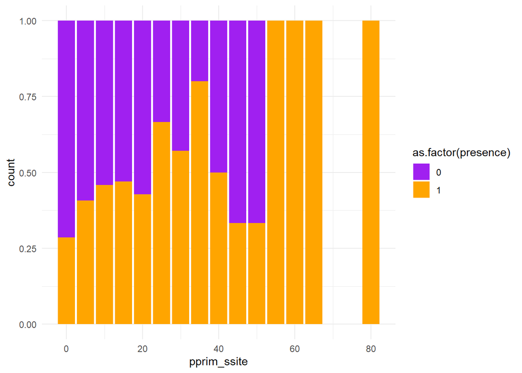

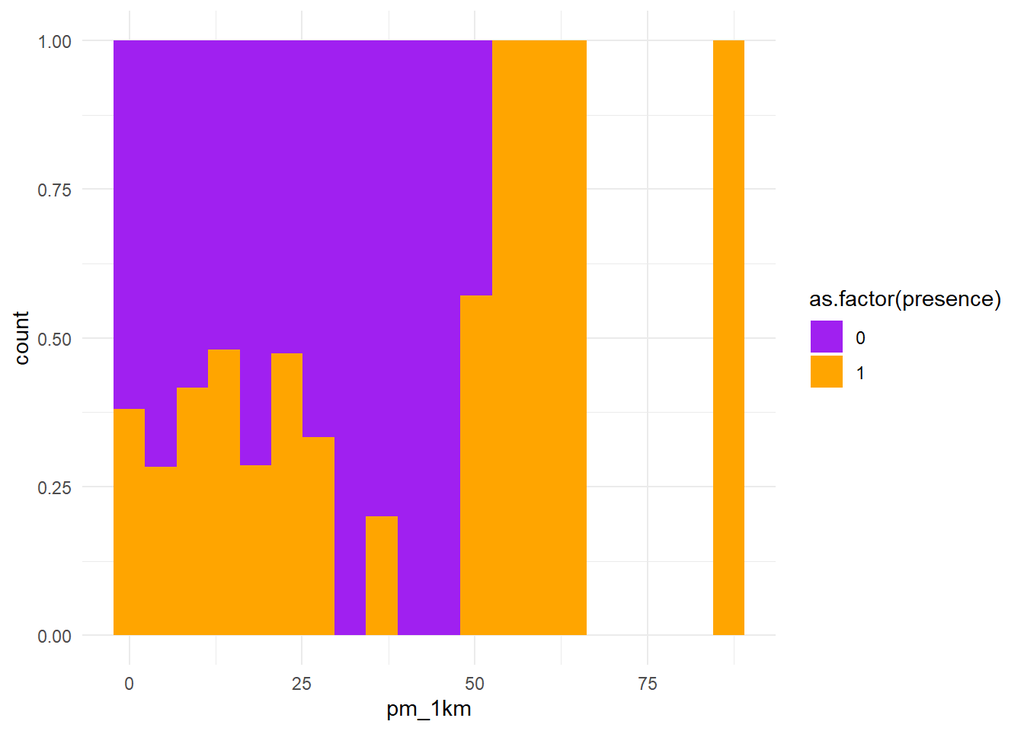

```r
##Visualizando a incidência da porcentagem de floresta marginal na ocorrência
ggplot(dados, aes(x = pm_1km, fill = as.factor(presence))) +
  geom_histogram(position = "fill", bins = 20) +
  scale_fill_manual(values = c("purple", "orange")) +
  theme_minimal()
```

Podemos perceber que a incidência de ocorrência difere entre as proporções de árvores primárias e de floresta marginal

vamos verificar as outras duas variáveis:

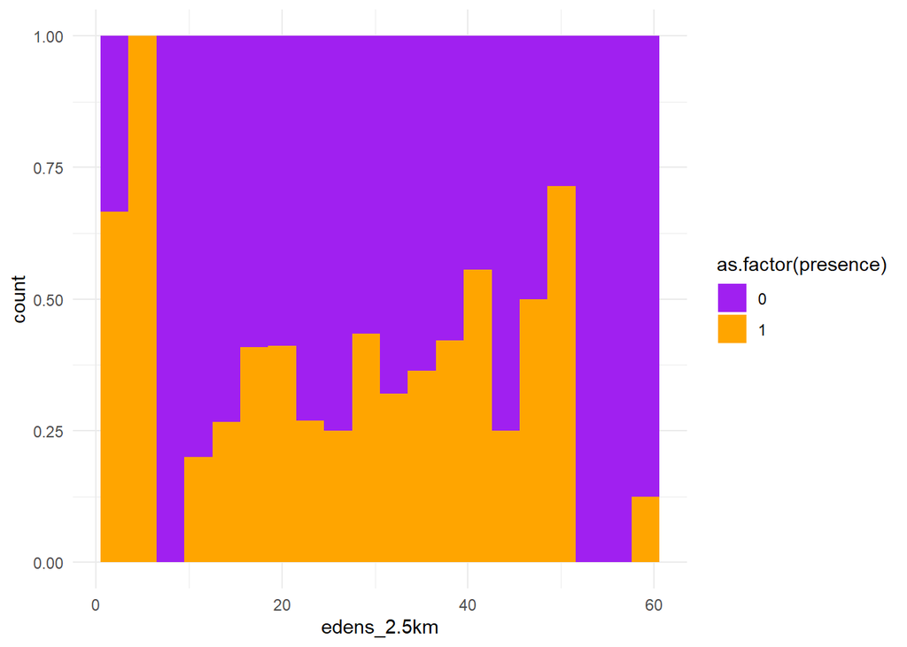

```r
ggplot(dados, aes(x = edens_2.5km, fill = as.factor(presence))) +
  geom_histogram(position = "fill", bins = 20) +
  scale_fill_manual(values = c("purple", "orange")) +
  theme_minimal()
```

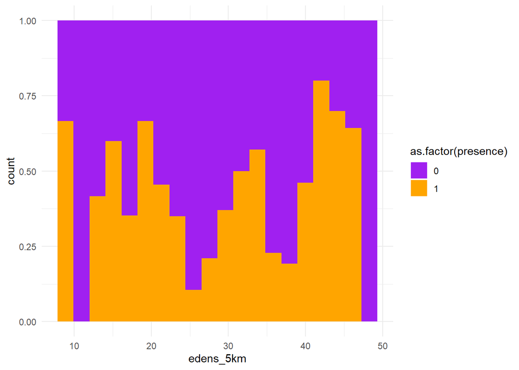

```r
ggplot(dados, aes(x = edens_5km, fill = as.factor(presence))) +
  geom_histogram(position = "fill", bins = 20) +
  scale_fill_manual(values = c("purple", "orange")) +
  theme_minimal()
```

## Hipóteses

Com as análises iniciais, podemos formar nossas hipóteses!

- $H_1:$ A porcentagem de árvores primárias influencia a ocorrência de coalas
- $H_2:$ A porcentagem de habitat marginal influencia a ocorrência de coalas
- $H_3:$ A densidade do efeito de borda influencia a ocorrência de coalas

##Objetivos

Avaliar como a qualidade de habitat (porcentagem de árvores primárias e porcentagem de habitat marginal) e a Urbanização (densidade do efeito de borda) influenciam na probabilidade de ocorrência de coalas na Austrália.

###Objetivos Específicos

1. **Avaliar o efeito da porcentagem de árvores primárias na probabilidade de presença de coalas**
   - Permitirá avaliar se sites com maiores porcentagens de árvores primárias tem maiores probabilidade de presença
2. **Avaliar o efeito da porcentagem de habitat marginal na probabilidade de presença de coalas**
   - Permitirá avaliar se sites com maiores porcentagens de habitat marginal tem maiores probabilidade de presença
3. **Avaliar o papel da densidade do efeito de borda na probabilidade de presença de coalas** - Permitirá avaliar se sites com maiores densidades de efeito de borda tem menores probabilidade de presença

## 5 Análises & Resultados

Iniciaremos as análises montando os modelos, partindo do modelo mais simples (modelo nulo) para o modelo mais complexo, contendo todas as covariáveis selecionadas.

```r
## Modelo Nulo
mod0 <- glm(presence ~ 1,
            family = binomial(link = "logit"),
            data = dados)

## Modelo 1
mod1 <- glm(presence ~ pprim_ssite,
            family = binomial(link = "logit"),
            data = dados)

## Modelo 2
mod2 <- glm(presence ~ pprim_ssite + pm_1km,
            family = binomial(link = "logit"),
            data = dados)

## Modelo 3
mod3 <- glm(presence ~ pprim_ssite + pm_1km + edens_2.5km,
            family = binomial(link = "logit"),
            data = dados)
## Modelo 4
mod4 <- glm(presence ~ pprim_ssite + pm_1km + edens_2.5km + edens_5km,
            family = binomial(link = "logit"),
            data = dados)
```

Tendo os modelos, vamos compará-los pelo valor de AIC:

```r
## Calcular os valores de AIC
aic <- AIC(mod0, mod1, mod2, mod3, mod4)


aic %>% arrange(AIC)
```

```
##      df      AIC
## mod4  5 381.6172
## mod2  3 384.2369
## mod3  4 386.0867
## mod1  2 388.3130
## mod0  1 400.4385
```

Analisando a tabela, o modelo com melhor ajuste foi o mod4, com todas as covariáveis, uma vez que ele apresentou menor valor de AIC.

Comparando com o segundo melhor modelo:

```r
## Teste de razão de verossimilhança

anova(mod4, mod2, test = "Chisq")
```

```
## Analysis of Deviance Table
##
## Model 1: presence ~ pprim_ssite + pm_1km + edens_2.5km + edens_5km
## Model 2: presence ~ pprim_ssite + pm_1km
##   Resid. Df Resid. Dev Df Deviance Pr(>Chi)
## 1       295     371.62
## 2       297     378.24 -2  -6.6197  0.03652 *
## ---
## Signif. codes:  0 '***' 0.001 '**' 0.01 '*' 0.05 '.' 0.1 ' ' 1
```

P < 0.05, o modelo mais complexo (mod4), com duas variáveis a mais, é melhor e mais ajustado que o modelo simples (mod2)

Análise gráfica:

Vamos fazer alguns testes, para verificar o ajuste do modelo.

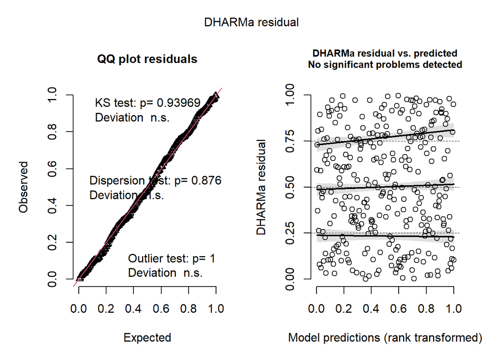

```r
library(DHARMa)

## Simulando os resíduos a partir do modelo escolhido

resid_sim <- simulateResiduals(mod4, n=1000)

plot(resid_sim)
```

Pelos valores de p, modelo não apresenta desvio significativo ou outlier, e possui dispersão adequada, ou seja, os resíduos estão bem distribuídos e o medelo se ajusta bem aos dados. Além disso, não há padrões ou tendências nos resíduos → o modelo não apresenta problemas como heterocedasticidade ou viés.

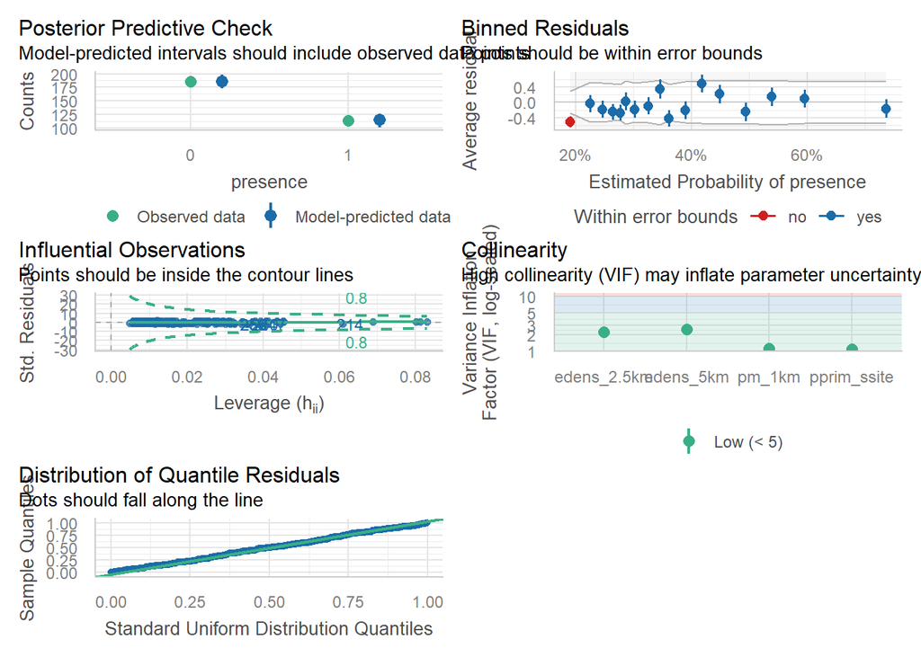

```r
library(performance)
check_model(mod4)
```

```r
summary(mod4)
```

```
##
## Call:
## glm(formula = presence ~ pprim_ssite + pm_1km + edens_2.5km +
##     edens_5km, family = binomial(link = "logit"), data = dados)
##
## Coefficients:
##              Estimate Std. Error z value Pr(>|z|)
## (Intercept) -1.882166   0.497316  -3.785 0.000154 ***
## pprim_ssite  0.043946   0.010717   4.101 4.12e-05 ***
## pm_1km       0.025561   0.008456   3.023 0.002504 **
## edens_2.5km -0.025295   0.015929  -1.588 0.112291
## edens_5km    0.050393   0.020068   2.511 0.012034 *
## ---
## Signif. codes:  0 '***' 0.001 '**' 0.01 '*' 0.05 '.' 0.1 ' ' 1
##
## (Dispersion parameter for binomial family taken to be 1)
##
##     Null deviance: 398.44  on 299  degrees of freedom
## Residual deviance: 371.62  on 295  degrees of freedom
## AIC: 381.62
##
## Number of Fisher Scoring iterations: 4
```

Para todos os gráficos acima tivemos um bom resultado. Reitera que o modelo reproduz bem os dados, não possui viés sistemático, ou observações com alta influência(Outliers). As variáveis não apresentam colinearidade significativa e os resíduos seguem a distribuição esperada.

```r
## Teste de autocorrelação
check_autocorrelation(mod4)
```

[output not shown]

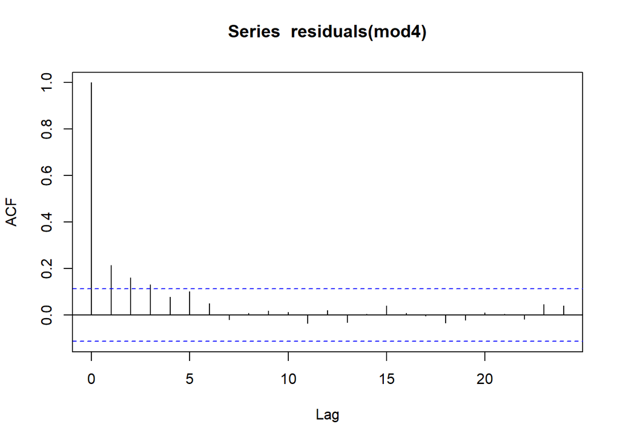

```r
acf(residuals(mod4))
```

Por fim, vamos interpretar os resultados:

```r
# Analisando os resultados
library(ggeffects)
names(mod4)
```

```
##  [1] "coefficients"      "residuals"         "fitted.values"
##  [4] "effects"           "R"                 "rank"
##  [7] "qr"                "family"            "linear.predictors"
## [10] "deviance"          "aic"               "null.deviance"
## [13] "iter"              "weights"           "prior.weights"
## [16] "df.residual"       "df.null"           "y"
## [19] "converged"         "boundary"          "model"
## [22] "call"              "formula"           "terms"
## [25] "data"              "offset"            "control"
## [28] "method"            "contrasts"         "xlevels"
```

```r
head(cbind(mod4$fitted.values, mod4$linear.predictors))
```

```
##        [,1]       [,2]
## 2 0.6538138  0.6358459
## 3 0.6443363  0.5942350
## 4 0.6365944  0.5606133
## 5 0.4249979 -0.3022896
## 6 0.4170211 -0.3350144
## 7 0.4095230 -0.3659376
```

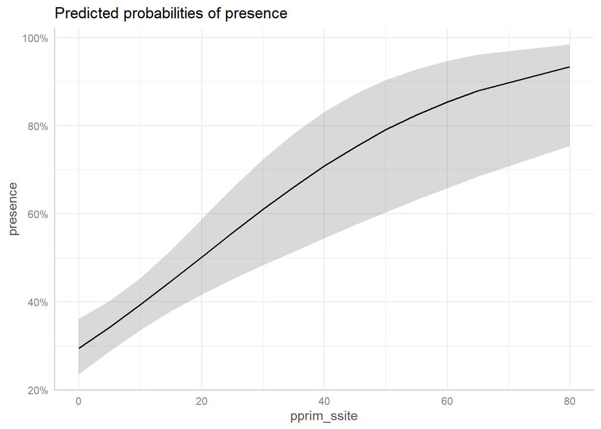

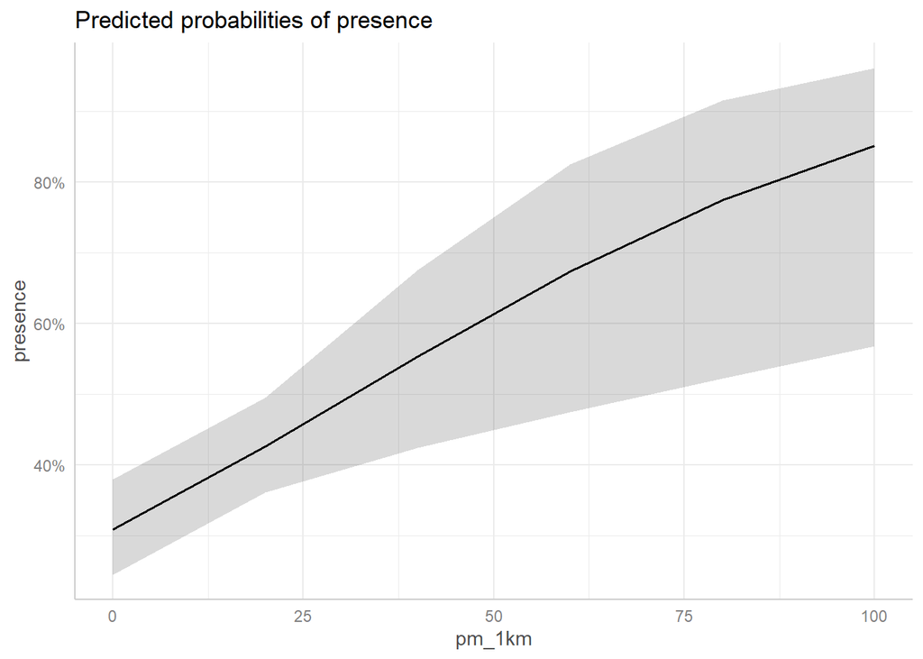

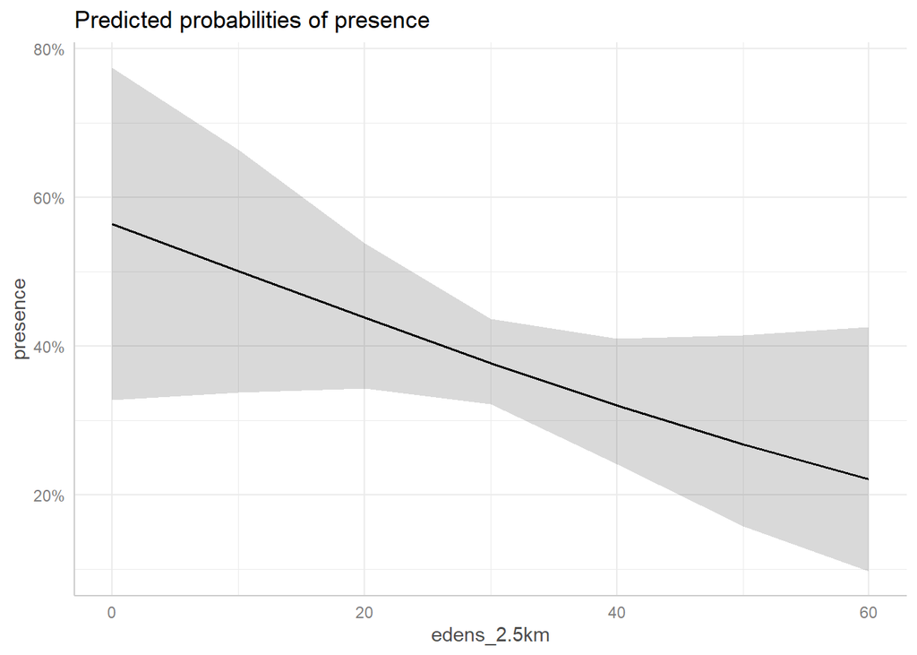

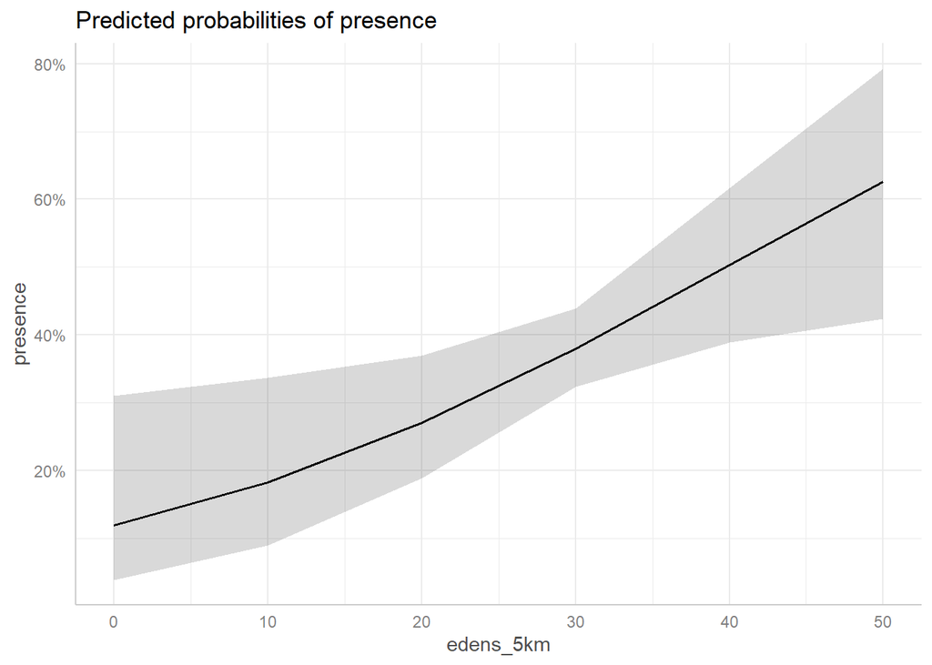

```r
ggpredict(mod4) %>% plot()
```

As porcentagens de áreas primárias, floresta marginal e densidade de borda na escala de 5km foram relacionadas positivamente à presença de coalas na Austrália. Já a Porcentagem de densidade do efeito de borda na escala 2.5km foi negativamente relacionada à presença de coalas.